# TOBS

Nadica Miljković

2024-05-17

Srednja vrednost učitanog EMG signala iz datoteke “*emg-kabl.txt*” je -0.02 mV. Signal je prikazan na sledećem grafiku:

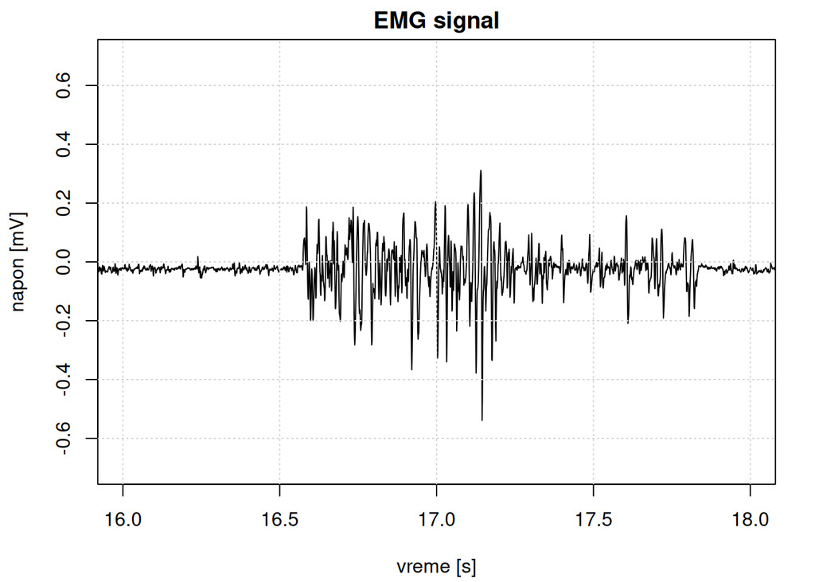

Datoteka sadrži ukupno 54263 odbiraka, odnosno snimanje je izvršeno u trajanju od 54.26 s. U ovom izveštaju analiziraće se jedna mišićna kontrakcija koja je izvršena u periodu od 16 s do 18 s. Furijeova transformacija signala primenom FFT metode (eng. *Fast Fourier Transform*) je prikazana na sledećem grafiku:

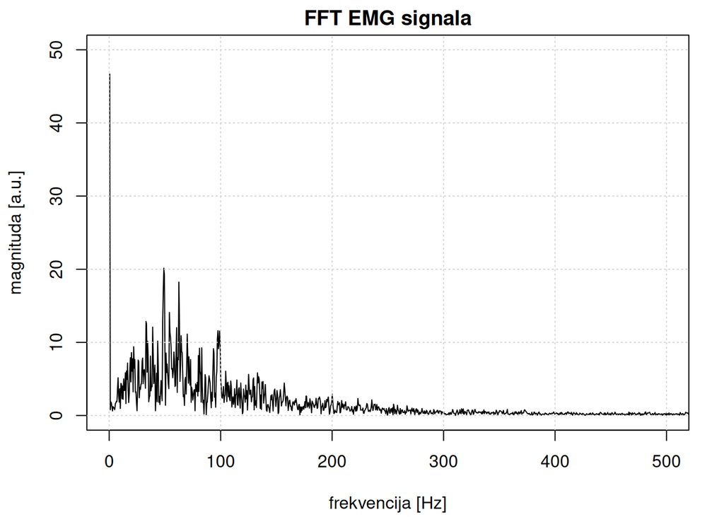

Kako bi se uklonio niskofrekventni šum koji dominantno potiče od pomeranja kablova, potrebno je primeniti Butervortov filtar. FFT filtriranog signala je prikazana zajedno sa FFT-om snimljenog signala na sledećem grafiku:

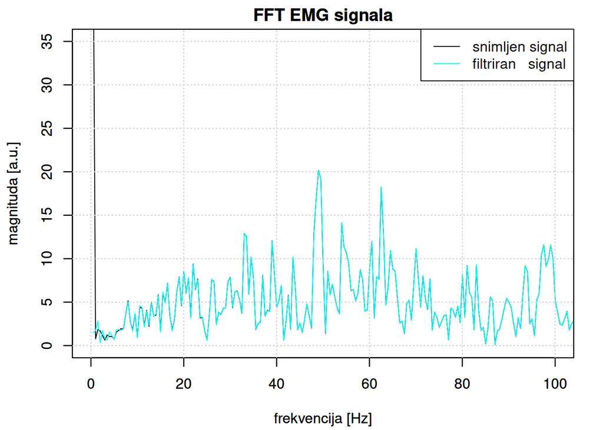

Za filtriranje je korišćen filtar visokopropusnik (eng. *high pass filter*) 3. reda sa frekvencijom odsecanja na 1 Hz. Dalje, potrebno je odrediti obvojnicu EMG signala. To se najjednostavnije postiže primenom filtra niskopropusnika (eng. *low pass filter*). Na sledećoj slici prikazana je obvojnica EMG signala zajedno sa dvostrano ispravljenim i filtriranim EMG signalom.

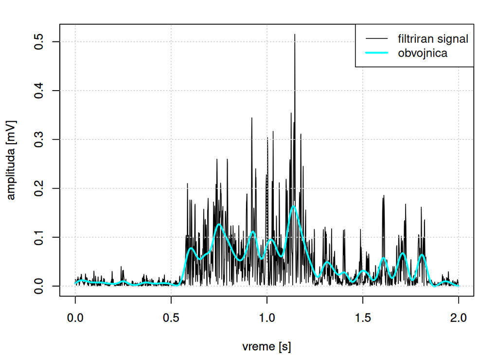

Sada je potrebno na osnovu dobijene obvojnice odrediti trenutak relaksacije i trenutak kontrakcije. To će u ovom primeru biti urađeno primenom pracma (eng. *Practical Numerical Math Functions*) paketa sa CRAN-a https://cran.r-project.org/package=pracma (pristupljeno 17.05.2024).

```r
library(pracma)
# Pogledati Help stranicu za funkciju findpeaks() kako bi se razumeo izlaz iz funkcije
t <- findpeaks(EMGa, minpeakheight = 2*sd(EMGa))
pocetak <- t[1,2] / fs # da bi bilo u s
kraj <- t[length(t[,1]),2] / fs
```

Na sledećoj slici je prikazano kako je ova funkcija detektovala početak i kraj mišićne kontrakcije. Primetiti da je u prethodnom kodu korišćena granica u vrednosti dve standardne devijacije obvojnice EMG signala kao prag. To u ovom slučaju iznosi 0.08 mV.

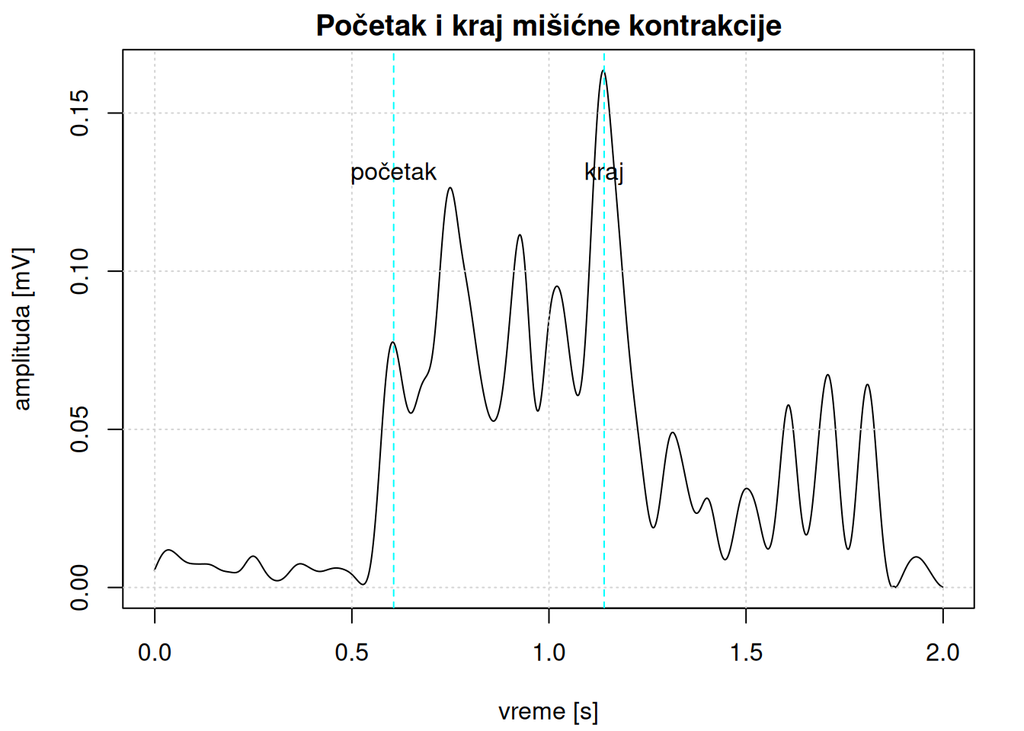

**NAPOMENA**: Za određivanje obvojnice EMG signala korišćen je Batervortov filtar frekvencije odsecanja 12 Hz i 3. reda. Na raspolaganju su bili dostupni podaci da je signal sniman sa frekvencijom odabiranja od 1000 Hz i sa pojačanjem od 1000 puta.